# The Journey from Wild to Textbook Data: A Case Study from the National Longitudinal Survey of Youth

24/02/2021

Abstract

The National Longitudinal Survey of Youth (NLSY79) is a prominent open data source that has been important for educational purposes and multidisciplinary research on longitudinal data. Subsets of this data can be found in numerous textbooks and research articles. However, the steps and decisions taken to get from the raw data to the textbook data is never clearly articulated. This article describes our journey when trying to re-create a textbook example data set from the original database, with the goal being to refresh the textbook data more regularly. Thus, this paper demonstrates the process – extracting, tidying, cleaning, and exploring with documentation – to make refreshed data available for education or research. Three new data sets, and the code to produce them are provided in an accompanying open source R package, called . As a result of this process, some recommendations are also made for the NLSY79 curators for incorporating data quality checks, and providing more convenient samples of the data to potential users.

```r
CENSOR <- TRUE
yowie <- ifelse(CENSOR, "\\texttt{[CENSORED]}", "\\texttt{yowie}")
yowie_repo <- ifelse(CENSOR, "CENSORED", "https://github.com/numbats/yowie")
yowie_pkgdown <- ifelse(CENSOR, "CENSORED", "https://github.com/numbats/yowie")
yowie_shiny <- ifelse(CENSOR, "CENSORED", "https://ebsmonash.shinyapps.io/yowie_app/")
```

# Introduction

“Open data” is data that is freely accessible, modifiable, and shareable by anyone for any purpose [@opendata]. This type of data can be useful as example data in statistical textbooks and for research purposes. However, open data is often referred to as what we might call “wild data” because it requires substantial cleaning and tidying to tame it into textbook shape. @HuebnerMariannePhD2016Asat emphasize that making the data cleaning process accountable and transparent is imperative and essential for the integrity of downstream statistical analyses and model building [@HuebnerMarianne2020Haar]. Data cleaning can be considered to be a part of what is called “initial data analysis” (IDA) [@Chatfield1985TIEo]. In IDA one would also explore the data, especially to check if the data is consistent with assumptions required for modeling. This is also related to exploratory data analysis (EDA), coined by @tukey with a focus on learning from data. EDA can be considered to encompass IDA. @DasuTamraparni2003Edma say that data cleaning and exploration, without naming it as IDA, is a difficult task and consumes 80% of the data mining task.

Despite it’s importance, this IDA stage is often undervalued and neglected [@Chatfield1985TIEo]. There are few research papers that document the data cleaning [@WickhamHadley2014TD]. Furthermore, the decisions made in this stage often go unreported in the sense that IDA is often performed in an unplanned and unstructured way and is only shared among restricted parties [@HuebnerMarianne2020Haar].

This paper demonstrates the steps of IDA, and documents the process, for a prominent open data source, National Longitudinal Survey of Youth 1979, henceforth referred to NLSY79. This data has been playing an important role in research in various disciplines, including but are not limited to economics, sociology, education, public policy, and public health for more than a quarter of the century [@MichaelRPergamit2001DWTN]. In addition, this is considered a carefully designed longitudinal survey with high retention rates, making it suitable for life course research [@MichaelRPergamit2001DWTN; @eliznlsy]. According to @eliznlsy, thousands of articles, and hundreds of book chapters and monographs have utilized this data. Moreover, the NLSY79 is considered the most widely used and most important cohort in the survey data [@MichaelRPergamit2001DWTN].

Our process of cleaning builds heavily on the tidyverse approach [@tidyverse]. The data is first organised into “tidy data” [@WickhamHadley2014TD] and then further wrangled using the data pipeline and split-apply-combine approach [@plyr]. The resulting data is provided in a new R package called `yowie` which includes the code so that the process is reproducible, and could be used to further refresh the data as new records are made available in the NLSY79 database.

This paper is structured in the following way. Section @ref(database) describes the NLSY79 data source. Section @ref(cleaning) presents the steps of cleaning the data, including getting and tidying the data from the NLSY79 and IDA to find and repair anomalies. Our final subset is compared the old textbook subset in Section @ref(compare). Finally, Section @ref(summary) summarizes the contribution and makes recommendations for the NLSY79 data curators.

# The NLSY79

## Database

The NLSY79 is a longitudinal survey held by the U.S Bureau of Labor Statistics that follows the lives of a sample of American youth born between 1957-1964 [@nlsy79]. The cohort originally included 12,686 respondents aged 14-22 when first interviewed in 1979. It comprised of Blacks, Hispanics, economically disadvantaged non-Black non-Hispanics, and youth in the military. In 1984 and 1990, two sub-samples were dropped from the interview; the dropped subjects are the 1,079 members of the military sample and 1,643 members of the economically disadvantaged non-Black non-Hispanics, respectively. Hence, 9,964 respondents remain in the eligible samples. The surveys were conducted annually from 1979 to 1994 and biennially thereafter. Data are currently available from Round 1 (1979 survey year) to Round 28 (2018 survey year).

Although the main focus area of the NLSY is labor and employment, the NLSY also covers several other topics, including education; training and achievement; household, geography, and contextual variables; dating, marriage, cohabitation; sexual activity, pregnancy, and fertility; children; income, assets and program participation; health; attitudes and expectations; and crime and substance use.

There are two ways to conduct the interview of the NLSY79, which are face-to-face interviews or by telephone. In recent survey years, more than 90 percent of respondents were interviewed by telephone [@eliznlsy].

## Target data

# Data cleaning

@LooMarkvander2018Sdcw describe the notion of a “statistical value chain” where the production stages of data cleaning process are earmarked as raw data (data from the data source), input data (data organised with correct type and identified variables) and valid data (data that faithfully represent the variables). In this section, we outline the steps to download the raw data (Section @ref(getdata)) and then tidying the raw data into input data, specifically for wages data (Section @ref(tidywages)), demographic variables (Section @ref(tidydemog)) and the employment variables (Section @ref(tidyemp)), so that the resulting input data can be used downstream for validating the data as described in Section @ref(ida).

## Getting the data

The NLSY79 data contains a large scope of variables but for our aim, the scope required is limited to demographic profiles and wages data. More specifically, we went to the NLSY79 database website at , clicked on the direct link to NSLY79 data and navigated as described below.

NLSY79 ()  
The CASEID will be always be selected.  
The 3 recommended demographic variable (sample ID, race and sex) were selected.  
For the remaining variables, we went to the “Variable Search” tab and select variables as follows

The downloaded data set comes as a zip file, containing the following set of files:

- `NLSY79.csv`: csv format of the response data,
- `NLSY79.dat`: dat format of the response data,
- `NLSY79.NLSY79`: Tagset of variables that can be uploaded to the website to recreate the data set, and
- `NLSY79.R`: R script for reading the data into R and converting the variables’ names and label into something more sensible.

We only alter the file path in `NLSY79.R` and run the script without any other alteration. This results in an initial processing of the raw data into two data set, `categories_qnames` (where the observations are stored in categorical/interval values) and `new_data_qnames` (the observations are stored in integer form).

The raw data, `new_data_qnames`, is organised such that each row corresponds to an individual. As respondents can have multiple jobs at specific years, the column names, such as `HRP1_1979`, `HRP2_1979`, `HRP1_1980` and `HRP2_1980`, contain the information about the job number up to 5 (`HRP1` = job 1, `HRP2` = job 2) and the year. The raw data consequently has a large number of columns (686 to be specific). The values in the cell under the variables that begin with `HRP` correspond to the hourly wage in dollars. A glimpse of this data output is shown below.

```
#> 'data.frame':    12686 obs. of  686 variables:
#>  $ CASEID_1979                  : int  1 2 3 4 5 6 7 8 9 10 ...
#>  $ HRP1_1979                    : int  328 385 365 NA 310 NA NA NA 214 NA ...
#>  $ HRP2_1979                    : int  NA NA NA NA 375 NA NA NA NA NA ...
#>  $ HRP3_1979                    : int  NA NA 275 NA NA NA NA NA NA NA ...
#>  $ HRP4_1979                    : int  NA NA NA NA NA 250 NA NA NA NA ...
#>  $ HRP5_1979                    : int  NA NA NA NA NA NA NA NA NA NA ...
#>  $ HRP1_1980                    : int  NA 457 397 NA 333 275 300 394 200 318 ...
#>  $ HRP2_1980                    : int  NA NA 367 NA NA NA NA NA NA NA ...
#>  $ HRP3_1980                    : int  NA NA 380 NA NA NA 290 NA NA NA ...
#>  $ HRP4_1980                    : int  NA NA NA NA NA NA NA NA NA NA ...
#>   [list output truncated]
```

According to @WickhamHadley2014TD, tidy data sets comply with three rules: (i) each variable forms a column, (ii) each observation forms a row, and (iii) each type of observational unit forms a table. The raw data does not comply these rules, thus we re-arrange and wrangle the data into tidy data form, columns corresponding to individual ID, year, job number, wage in dollars and the demographic variables. This is done using the `tidyverse` suite of packages [@tidyverse], `tidyr` [@tidyr] to pivot the data into long form, `dplyr` [@dplyr], and `stringr` [@stringr] for creating new variables, and levels of factors by text wrangling. The long form of the data makes it possible to do these data transformations efficiently, and it is an intermediate step towards the final target data. The code for tidying the data are demonstrated at but also described in the subsequent subsections.

### Tidying demographic variables

In our final target data, we wish to include the demographic variables with variable names specified in brackets: gender (`gender`), race (`race`), age (`age_1979`), highest grade completed (`hgc`), highest grade completed in terms of years, e.g. 9th grade = 9, 3rd year college = 15, (`hgc_i`) and the corresponding year this grade was completed (`yr_hgc`).

For gender and race, we only rename the column names. It is worth noting that using these two variable needs special attention. Gender, as reported in the data, only has two categories, which is recognised today as inadequate. Gender is not binary. Further, race is as reported in the database. When doing analysis with this variable, one should keep in mind that the purpose is to study racism rather than race.

The `new_data_qnames` contains the variables `Q1-3_A~Y_1979` and `Q1-3_A~Y_1981` which records two versions of the birth year of the respondent; this is also the case for the record of birth month (`Q1-3_A~M_1979` and `Q1-3_A~M_1981`). The record contains two versions of birth year and birth month as the survey recorded this in 1979 and 1981. We checked for consistency for the two versions and found no discrepancy where the responses were recorded in both 1979 and 1981. The age was then calculated using the birth year.

The next step is tidying the highest grade completed (`hgc`) variable. This variable came with several version in each year. We choose the revised May data because it seemed to have less missing and presumably has been checked. However, there is no revised May data for 2012, 2014, 2016, and 2018, thus, we use the ordinary May data for these years. The code for tidying this variable is provided in the supplementary materials.

Furthermore, `hgc` is measured and could be updated in each period of the survey. Hence, we only used the highest grade completed ever and derived the year when it is completed. The code for deriving this variable is also available at .

Finally, we get all of the demographic profiles of the NLSY79 cohort. We then save this data as `demog_nlsy79`.

### Tidying employment variables

The employment data comprises of three variables, i.e., `total hours of work per week`, `number of jobs that an individual has`, and `mean hourly wage`.

`hours worked per week` initially has only one version per job, no choice from 1979 to 1987 (QES-52A). From 1988 onward, when we had more options, we chose the variable for total hours, including time spent working from home (QES-52D). However, in 1993, this variable did not have all the five D variables (the first one and the last one were missing), so we used QES-52A variable instead. In addition, 2008 only had jobs 1-4 for the QES-52D variable (whereas the other years had 1-5), so we use these.

The same way was also deployed to tidy the rate of wage by year and by ID. The difference is that the hourly rate has only one version of each year. The hours of work and the hourly rate are then joined to calculate the number of jobs that a respondent has and their mean hourly wage. Some observations have 0 in their hourly rate and work hours, which is considered an invalid value. Thus, these observations are set to be NA. Besides, there are some observations with unusual hours of work. Here, we also censored the observations with > 84 hours of work a week to be NA.

Since our ultimate goal is to calculate the mean hourly wage, the number of jobs is calculated based on the availability of the `rate_per_hour` information. For example, the number of jobs of ID 1, based on `hours_work`, is 2. However, since the information of hourly rate of `job_02` is not available, the number of jobs is considered as 1.

Further, we calculated the mean hourly wage for each ID in each year using a weighted mean with the hours of work as the weight. However, there is a lot of missing value in `hours_work` variable. In that case, we only calculated the mean hourly wage based on the arithmetic/regular mean method. Hence, we created a new variable to flag whether the mean hourly wage is weighted or regular. Additionally, if an ID only had one job, we directly used their hourly wages information and flagged it as arithmetic mean.

```
#> # A tibble: 10 × 6
#>       id  year mean_hourly_wage total_hours number_of_jobs is_wm
#>    <int> <dbl>            <dbl>       <int>          <dbl> <lgl>
#>  1     1  1979             3.28          38              1 FALSE
#>  2     1  1981             3.61          NA              1 FALSE
#>  3     2  1979             3.85          35              1 FALSE
#>  4     2  1980             4.57          NA              1 FALSE
#>  5     2  1981             5.14          NA              1 FALSE
#>  6     2  1982             5.71          35              1 FALSE
#>  7     2  1983             5.71          NA              1 FALSE
#>  8     2  1984             5.14          NA              1 FALSE
#>  9     2  1985             7.71          NA              1 FALSE
#> 10     2  1986             7.69          NA              1 FALSE
```

The employment and demographic variables are then joined. We also filtered the data to only have the cohort who completed the education up to 12th grade and participated at least five rounds in the survey and save it to an object called `wages`.

## Initial data analysis

According to @HuebnerMariannePhD2016Asat, initial data analysis (IDA) is the step of inspecting and screening the data after being collected to ensure that the data is clean, valid, and ready to be deployed in the later formal statistical analysis. Moreover, @Chatfield1985TIEo argues that the two main objectives of IDA are data description, which is to assess the structure and the quality of the data, and model formulation without any formal statistical inference.

In this paper, we conduct an IDA or a preliminary data analysis to assess the consistency of the data with the cohort information that the NLSY provides. In addition, we also aim to find the anomaly in the wages values using this approach. We mainly use graphical summaries to do the IDA using `ggplot2` [@ggplot2] and `brolgar` [@brolgar].

| Age | Number of individuals |
| --- | --- |
| 15 | 1,265 |
| 16 | 1,550 |
| 17 | 1,600 |
| 18 | 1,530 |
| 19 | 1,662 |
| 20 | 1,722 |
| 21 | 1,677 |
| 22 | 1,680 |

The contingency table for gender and race for the full NLSY79 data.

| Gender | Race Hispanic | Race Black | Race Non-Black, Non-Hispanic | Total |
| --- | --- | --- | --- | --- |
| Male | 1,000 (15.62%) | 1,613 (25.19%) | 3,790 (59.19%) | 6,403 (100.00%) |
| Female | 1,002 (15.95%) | 1,561 (24.84%) | 3,720 (59.21%) | 6,283 (100.00%) |
| Total | 2,002 (15.78%) | 3,174 (25.02%) | 7,510 (59.20%) | 12,686 (100.00%) |

The next step is that explore the mean hourly wage data. In this case, we only explore the wages data of up to $12^{th}$ grade. Here, we use visualisation techniques to do IDA.

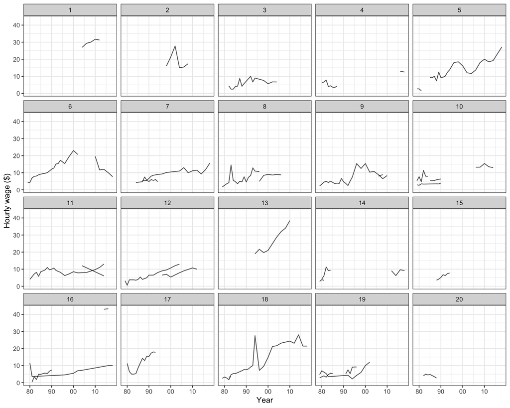

Longitudinal profiles of wages for a random sample of 20 individuals in the refreshed data. Most, but not all, individuals here experienced increasing wages over time, and several have experienced considerable fluctuation in wages. Some individuals are only measured for a short period.

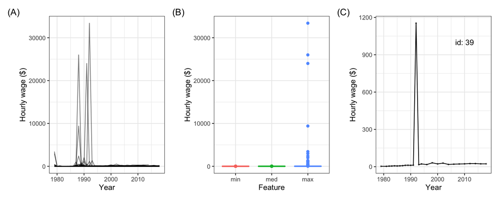

Summary plots to check the cleaned data reveal more cleaning is necessary: longitudinal profiles of wages for all individuals 1979-2018 (A), boxplots of minimum, median, and maximum wages of each individual (B), and one individual (id=39) with an unusual wage relative to their years of data (C). Some values of hourly wages are unbelievable, and some individuals have extemely unusual wages in some years.

The anomalies are also found in the total hours of work, where some observations work for 420 hours a week in total. According to @MichaelRPergamit2001DWTN, one of the flaws of the NLSY79 employment data is that the NLSY79 collects the information of the working hours since the last interview. Thus, it might be challenging for the respondents to track the within-job hours’ changes between survey years, especially for the respondents with fluctuated working hours or seasonal jobs. It even has been more challenging since 1994, where the respondents had to recall two years periods. This shortcoming might also contribute to the fluctuation of one’s wages data.

### Replacing extreme values

As part of the IDA, which is the model formulation, we build a robust linear regression model to treat the extreme values in the data. Robust linear regression yields an estimation robust to the influence of noise or contamination [@KollerManuel2016rARP]. It also aims to detect the contamination by weighting each observation based on how “well-behaved” they are, known as robustness weight. Observations with lower robustness weight are suggested as an outlier by this method [@KollerManuel2016rARP].

Since we work with longitudinal data, we build the model for each ID instead of the overall data. The robust mixed model could be the best model to be employed in this case. However, this method is too computationally and memory expensive, especially for a large data set, like the NLSY79 data. Thus, the model for each ID is built utilizing the `nest` and `map` function from `tidyr` [@tidyr] and `purrr` [@purrr], respectively.

We build the model using the `rlm` function from `MASS` package [@mass]. We set the `mean_hourly_wage` and `year` as the dependent and predictor, respectively. Furthermore, we use M-Estimation with Huber weighting, where the observation with a slight residual gets a weight of 1, while the larger the residual, the smaller the weight (less than 1) [@rlm]. However, the challenging part of detecting the anomaly using the robustness weight is determining the weight threshold in which the observations are considered outliers. Moreover, it should be noted that not all the outliers are due to an error. Instead, it might be that one had reasonably increasing or decreasing wages in a particular period.

To minimize the risk of mistakenly identifying an outlier as an “erroneous outlier”, we simulate some thresholds and study how they affect the data. We find that 0.12 is the most reasonable value to be the threshold to minimize that drawback’s risk because it still captures the sensible spikes in the data. In other words, we keep maintaining the natural variability of the wages while minimizing anomalies because of the error in the data recording. After deciding the threshold, we impute the observations whose weights are less than 0.12 with the models’ predicted value. We then flag those observations in a new variable called `is_pred`.

Figure shows the mean hourly wage before and after the extreme values are replaced. It implies that the fluctuation can still be observed in the data after the treatment. However, the large spikes, which are considered “erroneous outliers”, are already eliminated from the data. Hence, the model produces a data set with a more reasonable degree of fluctuation.

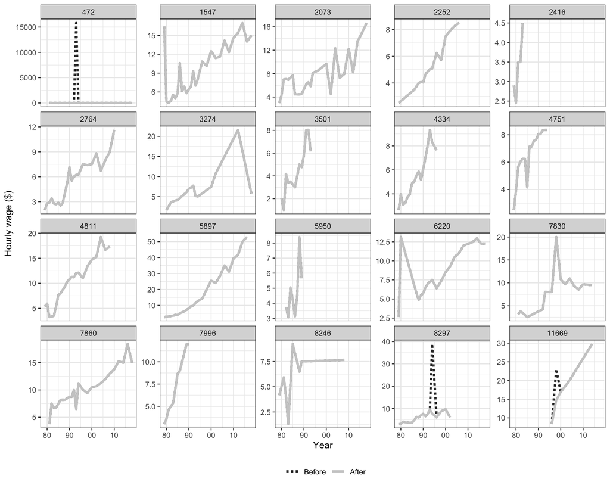

Comparison between the original (black dots) and the corrected (solid grey) mean hourly wage for a sample of individuals. A robust linear model prediction was used to correct mean hourly wages value. We can see that some extreme spikes, corresponding to implausible wages, have been replaced with values more similar to wages in neighboring years, but otherwise the profiles are not changed. Some spikes might remain when wage vaues are plausible.

Further, Figure A shows that after eliminating the extreme values, the highest value has decreased to be around $350. The spikes are still observed but not as extreme as the original data set. In Figure B, we plot the three features of mean hourly wages, namely the minimum, median, and maximum value. We still can see some extreme values in maximum wages, but consider it as a natural variability of the data. In Figure C, we can see that after imputing the extreme value in ID=39, we can see how the the wages change over the years more clearly.

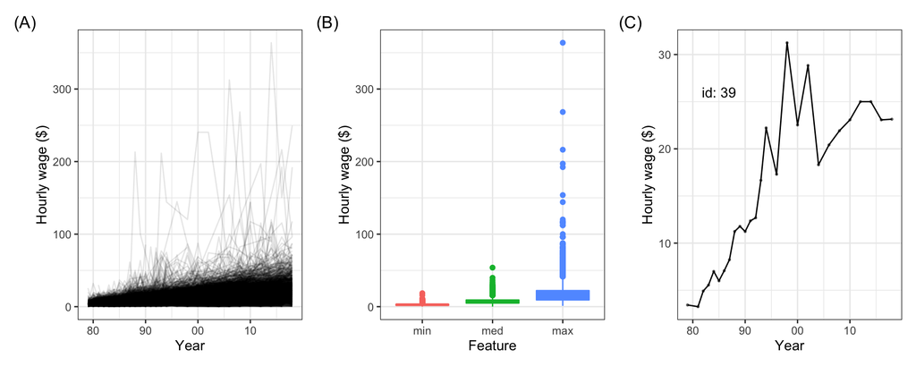

Re-make of the summary plots of the fully processed data suggest that it is now in a reasonable state: longitudinal profiles of wages for all individuals 1979-2018 (A), boxplots of minimum, median, and maximum wages of each individual (B), and one individual with an unusual wage relative to their years of data (C).

Finally, we save the imputed data and set the appropriate data type for the variables.

## Recap

Figure summarizes the steps taken to go from raw to input to valid data [@LooMarkvander2018Sdcw] to create a refreshed wages data set.

(ref:flow-chart) The stages of data cleaning from the raw data to get three datasets contained . # of individuals means the number of respondents included in each stage, while # of observations means the number of rows in the data. The color represents the stage of data cleaning in statistical value chain [@validate]. Pink, blue, and green represents the raw, input, and valid data, respectively.

[figure not shown]

# Comparison of refreshed with the original data

Now is the time to see how close we have come to the original textbook data. The original set contains wages of high school dropouts wages [@SingerJudithD2003Alda] from 1979 through to 1994. The refreshed data set for comparison is also wages on high school drop outs, over 1979 to 2018. The original set is available in the R package `brolgar` and the refreshed data is available in the R package .

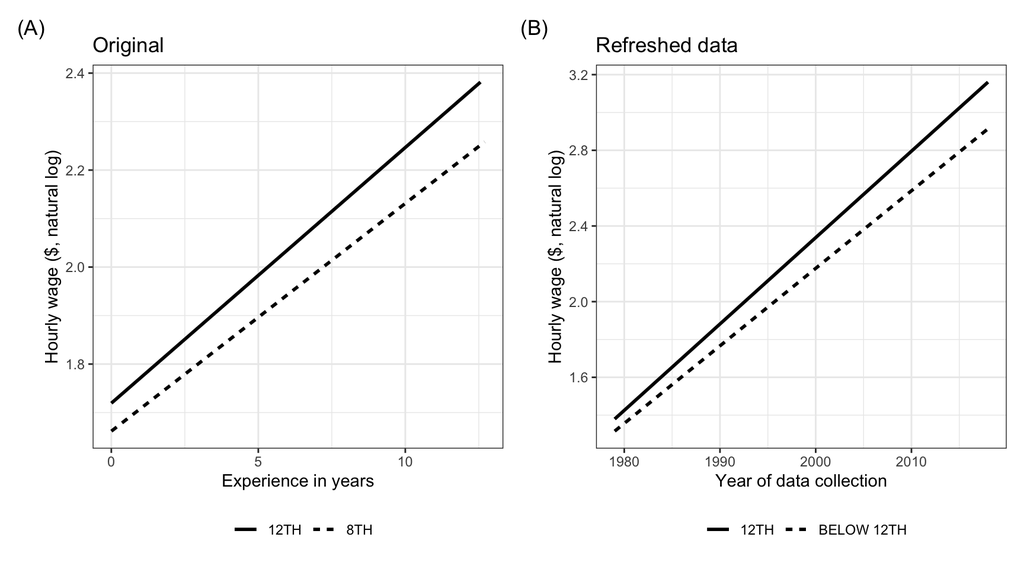

Comparison of original textbook example (A) with refreshed data (B). The original data was inflation-adjusted to 1990 prices and the individual’s time of collection was converted to a length of experience in the workforce, which make it difficult to precisely compare the two sets.

There are two aspects of the original data that make a direct comparison difficult. The time variable provided is “experience in the workforce”. It is not clear how this is calculated. One would expect that there is a record of the day the individual first started a job, and this is used to adjust the year of collection. We have not been able to find this information in the database. Secondly, wages were inflation-adjusted to 1990 prices, which is not done for the refreshed data.

The treatment of unlikely wages differ in the refreshed data. In the original data by @SingerJudithD2003Alda, wages greater than $75 are set to be missing. However, in recent context, this value is too low to be set as the maximum threshold. We opted to use the weights from a robust linear regression to determine what should be set as missing value as described in Section @ref(censor).

Figure shows a comparison of the two sets. (A direct ID matching is not possible.) There are 888 individuals in the original and 1,188 individuals in the refreshed data. This suggests some individuals were removed in the original data. In addition, in the original set the racial break down was 246 black, 204 hispanic and 438 white, while in the refreshed data there are 346 black, 219 hispanic and 623 white, so the proportions have not been exactly reproduced. On education, in the refreshed data there are very few individuals with less than a 12th grade education, which varies from the original. In the original data there were 366 individuals with up to 8th grade and 522 9th-12th grade, as compared to 967 with 12th grade in the refreshed data.

# Summary

This paper has described the stages to take a particular open data set and make it a textbook data set, ready for the classroom or research. In the first stage, we showed the steps performed to get the data from the NLSY79 database. The data format needed converting to tidy format, and this was described. After that, an initial data analysis was conducted to investigate and screen the quality of the data. We found and fixed the anomalous observations in wages using a robust linear regression model. Finally a comparison is made between the original and refreshed data sets.

The data cleaning process is documented and the code has been made available. These provide the opportunity to again refresh the textbook data as updated data is published in the NLSY79 database. Determining the appropriate robustness weight to threshold the anomalous observations is documented, and a `shiny` [@shiny] app is provided to assist. The current subset is made available in a new R package, called .

Various difficulties were encountered in trying to refresh the data, which include:

- determining which records should be downloaded from the database.
- there are many errors in the data, e.g. hourly wages greater than $30,000 per hour.
- there is no explicit variable in the database recording high school dropout, which means we needed to compare date of 12th grade with the individual’s age.
- calculating experience in the workforce, would require knowing the time of first job within the first year the individual was recorded.

Ultimately, the refreshed data is reasonably similar to the original, but unsatisfactorily far from it. The last step required would be to inflation-adjust wages, but this is better to do with each wave of new data added, so that it is relative to the last date in the data.

Some readers may disagree with our decisions made to produce the refreshed textbook data and may have better insight than us in producing a more appropriate textbook data. We do not assert that we have produced the best textbook data, but rather we describe our journey to provide a reasonable textbook data set. All code and documentation are provided for transparency, and future updates of the package may contain additional variables, or filters of the full set, if it is deemed important.

Finally, for the data providers we recommend that a validation system with clear rules is added on data entry, and that alternative output formats, such as a tidy format would help users make better use of the resource. The problem with many of the wages records is that there are implausible values, or confusion on how to record wages for multiple jobs. These values could be validated with simple checks at data entry. Providing an open data resource also is accompanied with the responsibility that the data, especially data that is as valuable as this, is reliable. Users need to be able to trust the data.

# Acknowledgements

We would like to thank Aarathy Babu for the insight and discussion during the writing of this paper.

The entire analysis is conducted using `R` [@R] in RStudio IDE using these packages: `tidyverse` [@tidyverse], `ggplot2` [@ggplot2], `dplyr` [@dplyr], `readr` [@readr], `tidyr` [@tidyr], `stringr` [@stringr], `purrr` [@purrr], `brolgar` [@brolgar], `patchwork` [@patchwork], `kableExtra` [@kableExtra], `MASS` [@mass], `janitor` [@janitor], and `tsibble` [@tsibble]. The paper are generated using `knitr` [@knitr] and `rmarkdown` [@rmarkdown].

# Supplementary Materials

- **Codes**: R script to reproduce data tidying and cleaning are available in this page.
- **R Package**: is a data container R package that contains 3 datasets, namely the high school mean hourly wage data, high school dropouts mean hourly wage data, and demographic data of the NLSY79 cohort. This package could be accessed here.
- **shiny app**: An interactive `shiny` web app to visualise the effect of selecting different weight threshold for substituting the wages data to its predicted value from a fit of the robust linear regression model. This app could be accessed here with the source code provided here.